# Lab report #1

*Question 1:* Variables Parcel ID; type chr, showing an id number for each observation Address; type chr, showing address of each sold house Style; type factor, showing architectural type of each sold house Occupancy; type factor, showing the occupancy type of each house (i.e., condo, townhome, etc.) Sale Date; type date, showing date of sale Sale Price; type num, showing price of each sale Multi sale; type chr, showing whether or not it was a multi sale YearBuilt; type num, showing year it was built Acres; type num, showing acreage of lot sold TotalLivingArea; type num, showing total square footage of house sold Bedrooms; type num, showing number of bedrooms FinishedBsmtArea; type num, showing square footage of finished basement LotArea; type num, showing square footage of lot AC; type chr, showing whether it has AC or not Fireplace; type chr, showing whether it has a fireplace or not Neighborhood; type Factor, showing what type of neighborhood it is located in

```r
max(ames$`Sale Price`, na.rm = FALSE)
```

```
## [1] 20500000
```

```r
min(ames$`Sale Price`, na.rm = FALSE)
```

```
## [1] 0
```

```r
library("ggplot2")
```

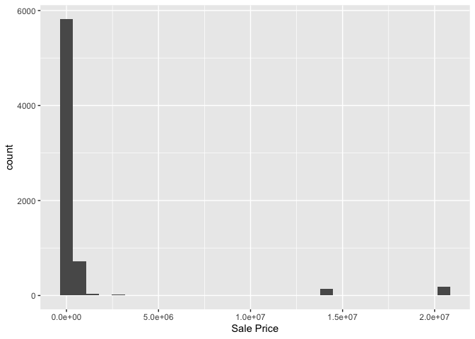

```r
ggplot(ames, aes(x = `Sale Price`)) +
  geom_histogram()
```

Amanda

```r
library("classdata")
ames
```

```
## # A tibble: 6,935 × 16
##    `Parcel ID` Address     Style Occupancy `Sale Date` `Sale Price` `Multi Sale`
##    <chr>       <chr>       <fct> <fct>     <date>             <dbl> <chr>
##  1 0903202160  1024 RIDGE… 1 1/… Single-F… 2022-08-12        181900 <NA>
##  2 0907428215  4503 TWAIN… 1 St… Condomin… 2022-08-04        127100 <NA>
##  3 0909428070  2030 MCCAR… 1 St… Single-F… 2022-08-15             0 <NA>
##  4 0923203160  3404 EMERA… 1 St… Townhouse 2022-08-09        245000 <NA>
##  5 0520440010  4507 EVERE… <NA>  <NA>      2022-08-03        449664 <NA>
##  6 0907275030  4512 HEMIN… 2 St… Single-F… 2022-08-16        368000 <NA>
##  7 0535105180  511 25TH S… 1 St… Single-F… 2022-08-03             0 <NA>
##  8 0907428446  4510 TWAIN… 1 St… Condomin… 2022-08-16        110000 <NA>
##  9 0527301030  3409 EISEN… 1 St… Single-F… 2022-08-08        350000 <NA>
## 10 0531363050  5426 KANSA… 1 St… Single-F… 2022-08-03        242000 <NA>
## # ℹ 6,925 more rows
## # ℹ 9 more variables: YearBuilt <dbl>, Acres <dbl>,
## #   `TotalLivingArea (sf)` <dbl>, Bedrooms <dbl>,
## #   `FinishedBsmtArea (sf)` <dbl>, `LotArea(sf)` <dbl>, AC <chr>,
## #   FirePlace <chr>, Neighborhood <fct>
```

2. some variabes of special interest would be sale price

*Question 4: Luke*

```r
max(ames$`FinishedBsmtArea (sf)`, na.rm = TRUE)
```

```
## [1] 6496
```

```r
min(ames$`FinishedBsmtArea (sf)`, na.rm = TRUE)
```

```
## [1] 10
```

```
## Warning: Removed 2682 rows containing non-finite values (`stat_bin()`).
```

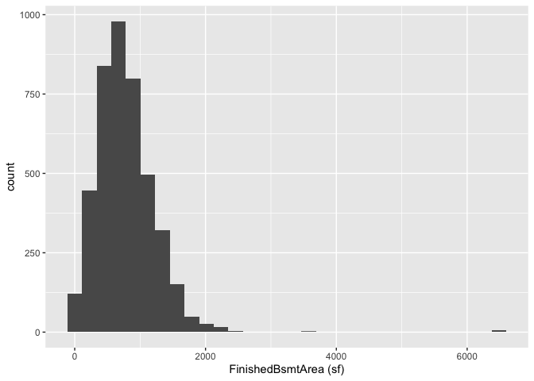

```r
ggplot(ames, aes(x = `FinishedBsmtArea (sf)`)) +
  geom_histogram()
```

[figure not shown]

```r
ggplot(ames, aes(x = 'FinishedBsmtArea (sf)', y = 'Sale Price')) +
  geom_point() +
  labs(title = "Scatterplot of Finished Basement Area vs. Sale Price",
       x = "Finished Basement Area (sf)",
       y = "Sale Price") +
  theme_minimal()
```

4. num of bedrooms compared to sales price

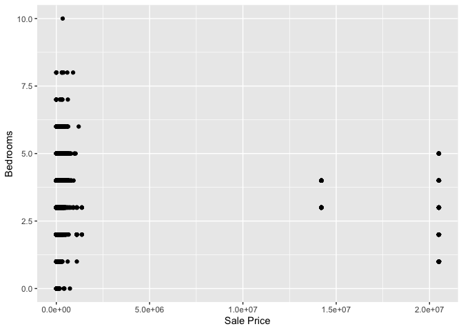

```r
ggplot(ames, aes(x = `Sale Price`, y = Bedrooms)) +
  geom_point()
```

*Question 4* I pick FinishedBsmtArea (sf).

Follow the instructions posted at https://ds202-at-isu.github.io/labs.html for the lab assignment. The work is meant to be finished during the lab time, but you have time until Monday evening to polish things.

Include your answers in this document (Rmd file). Make sure that it knits properly (into the md file). Upload both the Rmd and the md file to your repository.

```r
head(ames)
```

```
## # A tibble: 6 × 16
##   `Parcel ID` Address      Style Occupancy `Sale Date` `Sale Price` `Multi Sale`
##   <chr>       <chr>        <fct> <fct>     <date>             <dbl> <chr>
## 1 0903202160  1024 RIDGEW… 1 1/… Single-F… 2022-08-12        181900 <NA>
## 2 0907428215  4503 TWAIN … 1 St… Condomin… 2022-08-04        127100 <NA>
## 3 0909428070  2030 MCCART… 1 St… Single-F… 2022-08-15             0 <NA>
## 4 0923203160  3404 EMERAL… 1 St… Townhouse 2022-08-09        245000 <NA>
## 5 0520440010  4507 EVERES… <NA>  <NA>      2022-08-03        449664 <NA>
## 6 0907275030  4512 HEMING… 2 St… Single-F… 2022-08-16        368000 <NA>
## # ℹ 9 more variables: YearBuilt <dbl>, Acres <dbl>,
## #   `TotalLivingArea (sf)` <dbl>, Bedrooms <dbl>,
## #   `FinishedBsmtArea (sf)` <dbl>, `LotArea(sf)` <dbl>, AC <chr>,
## #   FirePlace <chr>, Neighborhood <fct>
```

```r
str(ames)
```

```
## tibble [6,935 × 16] (S3: tbl_df/tbl/data.frame)
##  $ Parcel ID            : chr [1:6935] "0903202160" "0907428215" "0909428070" "0923203160" ...
##  $ Address              : chr [1:6935] "1024 RIDGEWOOD AVE, AMES" "4503 TWAIN CIR UNIT 105, AMES" "2030 MCCARTHY RD, AMES" "3404 EMERALD DR, AMES" ...
##  $ Style                : Factor w/ 12 levels "1 1/2 Story Brick",..: 2 5 5 5 NA 9 5 5 5 5 ...
##  $ Occupancy            : Factor w/ 5 levels "Condominium",..: 2 1 2 3 NA 2 2 1 2 2 ...
##  $ Sale Date            : Date[1:6935], format: "2022-08-12" "2022-08-04" ...
##  $ Sale Price           : num [1:6935] 181900 127100 0 245000 449664 ...
##  $ Multi Sale           : chr [1:6935] NA NA NA NA ...
##  $ YearBuilt            : num [1:6935] 1940 2006 1951 1997 NA ...
##  $ Acres                : num [1:6935] 0.109 0.027 0.321 0.103 0.287 0.494 0.172 0.023 0.285 0.172 ...
##  $ TotalLivingArea (sf) : num [1:6935] 1030 771 1456 1289 NA ...
##  $ Bedrooms             : num [1:6935] 2 1 3 4 NA 4 5 1 3 4 ...
##  $ FinishedBsmtArea (sf): num [1:6935] NA NA 1261 890 NA ...
##  $ LotArea(sf)          : num [1:6935] 4740 1181 14000 4500 12493 ...
##  $ AC                   : chr [1:6935] "Yes" "Yes" "Yes" "Yes" ...
##  $ FirePlace            : chr [1:6935] "Yes" "No" "No" "No" ...
##  $ Neighborhood         : Factor w/ 42 levels "(0) None","(13) Apts: Campus",..: 15 40 19 18 6 24 14 40 13 23 ...
```

Jackson picked TotalLivingArea (sf)

```r
Range_TotalLivingArea <- range(ames$`TotalLivingArea (sf)`, na.rm = TRUE)
print(Range_TotalLivingArea)
```

```
## [1]    0 6007
```

```
## Warning: Removed 447 rows containing non-finite values (`stat_smooth()`).
```

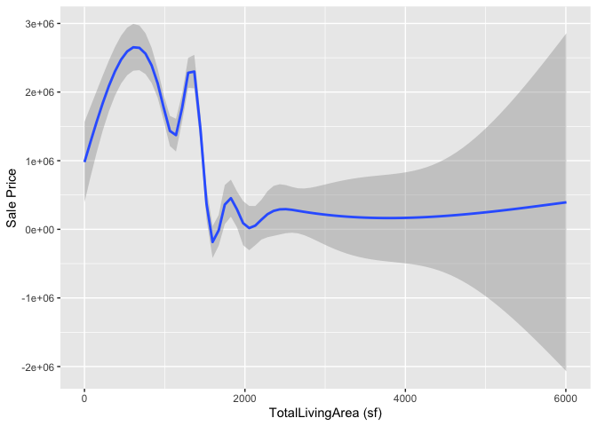

```r
ggplot(data = ames) +
  geom_smooth(mapping = aes(x = `TotalLivingArea (sf)`, y = `Sale Price`, ))
```

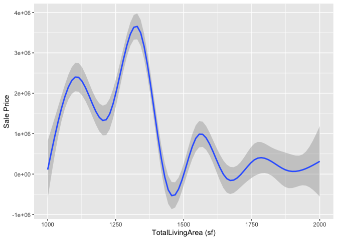

```r
TotalLivingArea_extremeSlopeChange <- subset(ames, `TotalLivingArea (sf)` >= 1000 & `TotalLivingArea (sf)` <= 2000)

ggplot(data = TotalLivingArea_extremeSlopeChange ) +
  geom_smooth(mapping = aes(x = `TotalLivingArea (sf)`, y = `Sale Price`, ))
```

The graph above tells me that the price per total living area in ft.^2 is higher around 0 - 1200, then after that the sales price goes down dramatically. Then the sales price flattens out around 2500 - 5000; then it starts to go back up again. The sales price per ft.^2 at the beginning is very high, its at its highest at around 750 ft.^2, then it has a dramatic drop around 1200 - 1500. This tells me there is a starting cost of a building that is automatically built into it or the supply and demand is very high, I would need more data to figure that out. The total living area from 1000 - 2000 sales price doesn’t reach near a constant, it’s constantly changing.

Brennan picked Style (sf)

```r
library(dplyr)
```

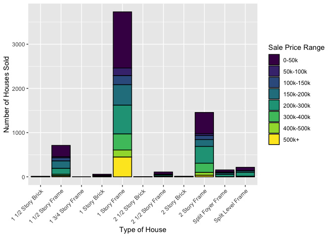

```r
ames <- ames %>%
  mutate(Price_Range = cut(`Sale Price`,
                           breaks = c(0, 50000, 100000, 150000, 200000, 300000, 400000, 500000, Inf),
                           labels = c("0-50k", "50k-100k", "100k-150k", "150k-200k", "200k-300k", "300k-400k", "400k-500k", "500k+"),
                           include.lowest = TRUE,
                           ordered_result = TRUE))
ames <- ames %>%
  filter(!is.na(Style) & Style != "None")

ggplot(ames, aes(x = Style, fill = Price_Range)) +
  geom_bar(position = "stack", color = "black") +
  theme(axis.text.x = element_text(angle = 45, hjust = 1)) +
  labs(y = "Number of Houses Sold", x = "Type of House", fill = "Sale Price Range")
```

The x-axis represents the different styles, while the y-axis represents the number of homes sold. Each bar on the graph represents a distinct style. The bars are divided or “stacked” into color-coded segments that represent different price ranges. The height of each individual segment within a bar corresponds to the number of houses of that specific style sold. Clearly, 0-50k was the most popular sale price. Additionally, one and two-story frame houses sold the most. And the most homes sold at 500k+ resided within the one-story frame house style.

All submissions to the github repo will be automatically uploaded for grading once the due date is passed. Submit a link to your repository on Canvas (only one submission per team) to signal to the instructors that you are done with your submission.